# Week 7 - Object Oriented Programming

```r
library(ggplot2)
library(scatterplot3d)
```

No discussion of R would be complete without an examination of the object oriented capabilities. The R programming community has embraced many of the same constructs found in other object oriented languages, so a good understanding of these topics and the creation of classes is crucial to unlocking more advanced parts of the language. This would include advanced simulations and the creation of new R packages.

This week’s assignment is about creating a farming simulation.

## Weekly Learning Objectives

Create an R script with the following components:

1. Create a S3 class named crops that will track soybeans, wheat, and corn harvests. Include a function to evaluate the mean of all three crops, and include a simple error handling routine.
2. Create a S4 class named workers that will track farm workers harvesting those same crops. Assume that each worker has a skillset that is unique to each crop, plus another set of workers that can harvest multiple types. Include a function that will provide summary information about those workers.
3. Create an inherited class based on one of the classes you have created.
4. Build a farming simulation based on the combination of both workers and crops. Use the classes that were created in the previous steps and have it set to calculate yearly projections. Create input variables for each of the components, and run the simulation for a five year cycle.

## 1. Create a S3 class for Crops (Farming Simulation)

S3 classes are one of the most tricky things to master in R. For those who may be familiar with object oriented programming language, the S4 class may be slightly easier to implement. In addition to the text, I would strongly encourage you to read the R documentation sections:

https://www.rdocumentation.org/packages/base/versions/3.6.1/topics/class https://www.rdocumentation.org/packages/base/versions/3.6.1/topics/UseMethod

#### Full Points

For full points you need to write a similar class.

- Create a constructor function
- Create a print function for the class
- Create the class

Given the difficulty of initial understanding of classes, there will be some flexibility in grading this section.

In this example, the class is dependent on a constructor function called crops. In that, we will setup a data frame that is used through the rest of the class. When you see the .crops functions, it will be referring to elements within this data frame.

```r
# A crops constructor.  Create one of these for your class.  This is executed when the first instance of the class
# is created.  In this case
crops <- function(aCropType,
                  aCropYield,
                  aYear,
                  aFieldNumber) {
  aLen <- length(aCropType)                                               # store the length of aCropType
  aDataFrame <- NULL                                                      # initialize aDataFrame
  if ((aLen != length(aCropYield) |                                       # Multiple OR statements (use the | character)
       (aLen != length(aYear)) | (aLen != length(aFieldNumber)))) {
    cat("Error: Parameters need to be of the same length!")               # Send out an error message
                                                                          #   This is your error handler!
  } else {
    aDataFrame <-                                                         # initialize your data frame
      data.frame(
        cropType = aCropType,
        cropYield = aCropYield,
        year = aYear,
        fieldNumber = aFieldNumber
      )
    class(aDataFrame) <- "crops"                                          # initialize your class using the dataframe
  }                                                                       # and call it crops
  return(aDataFrame)
}

# Implement a print function for the class
print.crops <- function(obj) {            #  This is extremely basic.
  aDF <- data.frame(unclass(obj))         #  Unclass the object, turn it into a dataframe
  print(aDF)                              #  Print the dataframe
}
```

#### New Class Functions

*New Functions*

- cropMean calculates the crop mean
- cropYearlyMean calculates the crop yearly mean
- addCrops adds or merges crops

*Default Functions*

- cropMean.default
- cropYearlMean.default
- addCrops.default

*Extending Functions*

- cropMean.crops
- cropYearlyMean.crops
- addCrops.crops

```r
# Create new class function
cropMean <- function(anObj) {
  UseMethod("cropMean")
}
# The default could have handled the mean, but built this to show a generic class and an extension
cropMean.default <- function(anObj) {
  cat("This is a generic function\n")
}
cropMean.crops <- function(anObj) {
  anObj <- data.frame(unclass(anObj))
  aResult <- mean(anObj$cropYield)
  return(aResult)
}


cropYearlyMean <- function(anObj) {
  UseMethod("cropYearlyMean")
}
cropYearlyMean.default <- function(anObj) {
  cat("This is a generic function\n")
}
cropYearlyMean.crops <- function(anObj) {
  anObj <- data.frame(unclass(anObj))
  aResult <- aggregate(anObj[, "cropYield"], list(year = anObj$year), mean)
  colnames(aResult) <- c("Year", "Mean")
  return(aResult)
}


# Create new addCrops class function.  This will add or merge crops into a single data structure.
addCrops <- function(anObj, aNewObj) {
  UseMethod("addCrops")
}
addCrops.default <- function(anObj, aNewObj) {
  cat("This is a generic function\n")
}

addCrops.crops <- function(anObj, aNewObj) {
  anObj <- data.frame(unclass(anObj))
  aNewObj <- data.frame(unclass(aNewObj))
  aResult <- rbind(anObj, aNewObj)
  class(aResult) <- "crops"
  return(aResult)
}
```

#### Testing the Crops S3 class

For the test of the error handling, we want to cause that problem. Instead of using five elements for the second parameter, we will use six.

```r
# Test new class
aTestCrop <- crops(             # NOTICE each of these have FIVE elements.  That is important!
    rep("soybeans", 5),         # Remember the use of the repeat function
    aCropYield = 6:10,          # Setup crop yields as numbers between 6 and 10
    aYear = c(1, 1, 1, 1, 1),   # Setup years as a concatenation of year 1
    aFieldNumber = 1:5          # Setup field number as 1 - 5
)
class(aTestCrop)
```

```
[1] "crops"
```

```r
cropMean(aTestCrop)
```

```
[1] 8
```

```r
aTestCrop
```

| cropType | cropYield | year | fieldNumber |
| --- | --- | --- | --- |
| soybeans | 6 | 1 | 1 |
| soybeans | 7 | 1 | 2 |
| soybeans | 8 | 1 | 3 |
| soybeans | 9 | 1 | 4 |
| soybeans | 10 | 1 | 5 |

```r
aNewTestCrop <- crops(rep("wheat", 5), 6:10, 1:5, 1:5)
aTestCrop <- addCrops(aTestCrop, aNewTestCrop)

aNewTestCrop <- crops(rep("corn", 10), 1:10, 1:10, 1:10)
aTestCrop <- addCrops(aTestCrop, aNewTestCrop)
cropMean(aTestCrop)
```

```
[1] 6.75
```

```r
cropYearlyMean(aTestCrop)
```

| Year | Mean |
| --- | --- |
| 1 | 6.714286 |
| 2 | 4.500000 |
| 3 | 5.500000 |
| 4 | 6.500000 |
| 5 | 7.500000 |
| 6 | 6.000000 |
| 7 | 7.000000 |
| 8 | 8.000000 |
| 9 | 9.000000 |
| 10 | 10.000000 |

```r
aTestCrop
```

| cropType | cropYield | year | fieldNumber |
| --- | --- | --- | --- |
| soybeans | 6 | 1 | 1 |
| soybeans | 7 | 1 | 2 |
| soybeans | 8 | 1 | 3 |
| soybeans | 9 | 1 | 4 |
| soybeans | 10 | 1 | 5 |
| wheat | 6 | 1 | 1 |
| wheat | 7 | 2 | 2 |
| wheat | 8 | 3 | 3 |
| wheat | 9 | 4 | 4 |
| wheat | 10 | 5 | 5 |

[output cut: 10 more lines]

```r
# Test Error Handling
aNewTestCrop <- crops(rep("soybeans", 5), 5:10, 1:5, 1:5)
```

```
Error: Parameters need to be of the same length!
```

## 2. Create a S4 class for Workers

Creating a S4 class is much easier. Again, I would strongly recommend you review the R Documentation talking about S4 methods and classes.

https://www.rdocumentation.org/packages/methods/versions/3.3.2/topics/Introduction

#### Full Points

For full points you need to write a similar class.

- Create a Farm Worker class. It should have an ID, Crop Skillset, and indicator for multiple types
- Create a generic function for worker summary
- Create an overridden worker summary for multiple types
- Create an add worker function
- Create an overridden add worker function

Given the difficulty of initial understanding of classes, there will be some flexibility in grading this section.

```r
setClass(
  "Farm_Worker",
  representation(
    ID = "numeric",
    Crop_Skillset = "character",
    Multiple_Types = "logical"
  )
)
Farm_Worker <- function(anId, aCrop_Skillset, aMultiple_Types) {
  aResult <-
    new(
      "Farm_Worker",
      ID = anId,
      Crop_Skillset = aCrop_Skillset,
      Multiple_Types = aMultiple_Types
    )
  return(aResult)
}

# Create new generic function
setGeneric("Worker_Summary",
           function(anObj) {
             standardGeneric("Worker_Summary")
           })
```

```
[1] "Worker_Summary"
```

```r
setMethod("Worker_Summary", "Farm_Worker",
          function(anObj) {
            ids <- slot(anObj, "ID")
            #    cat("Total number of workers: ",length(ids),"\n")
            multiSkilled <- sum(anObj@Multiple_Types)

            skillsetTable <-
              table(crop = anObj@Crop_Skillset,
                    multiSkill = anObj@Multiple_Types)
            #    print(skillsetTable)
            aResult <- data.frame(skillsetTable)
            return(aResult)
          })
setGeneric("Add_Worker",
           function(anObj, aNewObj) {
             standardGeneric("Add_Worker")
           })
```

```
[1] "Add_Worker"
```

```r
setMethod("Add_Worker", "Farm_Worker",
          function(anObj, aNewObj) {
            anIndex <- length(anObj@ID)
            anObj@ID <- append(anObj@ID, aNewObj@ID, anIndex)
            anObj@Crop_Skillset <-
              append(anObj@Crop_Skillset, aNewObj@Crop_Skillset, anIndex)
            anObj@Multiple_Types <-
              append(anObj@Multiple_Types, aNewObj@Multiple_Types, anIndex)
            return(anObj)
          })
```

#### Testing the S4 Worker Class

```r
cornWorkers <- Farm_Worker(1:10, rep("corn", 10), rep(FALSE, 10))
wheatWorkers <- Farm_Worker(11:15, rep("wheat", 5), rep(FALSE, 5))
soybeanWorkers <- Farm_Worker(16:20, rep("soybeans", 5), rep(FALSE, 5))
superWorkers <- Farm_Worker(21:25, rep("corn", 5), rep(TRUE, 5))
workers <- cornWorkers
workers <- Add_Worker(workers, wheatWorkers)
workers <- Add_Worker(workers, soybeanWorkers)
workers <- Add_Worker(workers, superWorkers)
aSummary <- Worker_Summary(workers)
aSummary
```

| crop | multiSkill | Freq |
| --- | --- | --- |
| corn | FALSE | 10 |
| soybeans | FALSE | 5 |
| wheat | FALSE | 5 |
| corn | TRUE | 5 |
| soybeans | TRUE | 0 |
| wheat | TRUE | 0 |

## 3. Create an inherited class

Creating an inherited class is relatively simple once you have mastered the creation of a class. Here we are going to create a FT Employee class that is inherited from the class Farm_Worker that we just created. We will then create a test to ensure it is working properly.

#### Full Points

For full points you need to write a similar function.

```r
setClass("FT Employee", contains = "Farm_Worker", representation(name = "character"))
aWorker2 <-
  new(
    "FT Employee",
    ID = 1,
    Crop_Skillset = "corn",
    Multiple_Types = FALSE,
    name = "Joe"
  )

# Test
aWorker2
```

```
An object of class "FT Employee"
Slot "name":
[1] "Joe"

Slot "ID":
[1] 1

Slot "Crop_Skillset":
[1] "corn"

Slot "Multiple_Types":
[1] FALSE
```

```r
class(aWorker2)
```

```
[1] "FT Employee"
attr(,"package")
[1] ".GlobalEnv"
```

```r
Worker_Summary(aWorker2)
```

| crop | multiSkill | Freq |
| --- | --- | --- |
| corn | FALSE | 1 |

```r
str(aWorker2)
```

```
Formal class 'FT Employee' [package ".GlobalEnv"] with 4 slots
  ..@ name          : chr "Joe"
  ..@ ID            : num 1
  ..@ Crop_Skillset : chr "corn"
  ..@ Multiple_Types: logi FALSE
```

## 4. Build a farming simulation based on the combination of workers and crops

FarmSim assumes it will take one worker per field to product 1 unit of yield. A value can be entered into either workerSD and/or fieldSD to introduce standard deviation into the simulation

#### Full Points

For full points you need to write a similar function.

First let’s run some cleanup:

```r
rm(cornWorkers)
rm(wheatWorkers)
rm(soybeanWorkers)
rm(superWorkers)
rm(workers)
rm(aSummary)
rm(aTestCrop)
rm(aNewTestCrop)
rm(aWorker2)
```

Now let’s build the simulator:

```r
farmSim <- function(cornWorkers = 0,
                    wheatWorkers = 0,
                    soybeanWorkers = 0,
                    multiSkilledWorkers = 0,
                    workerSD = 0,
                    cornFields = 0,
                    wheatFields = 0,
                    soybeanFields = 0,
                    fieldSD = 0,
                    yearsToSim = 1) {
  # Internal function to generate a work pool, with a normal distribution, for a year.  The work pool
  # changes are meant to simulate work force fluctuations.  Any negatives work force distributions are
  # voided out and set to zero.
  workPool <-
    function(cornWorkers = 0,
             wheatWorkers = 0,
             soybeanWorkers = 0,
             multiSkilledWorkers = 0,
             workerSD = 0) {
      nbrWorkers <- round(rnorm(1, cornWorkers, workerSD))
      if (nbrWorkers < 0)
        nbrWorkers = 0
      workers <-
        Farm_Worker(1:nbrWorkers,
                    rep("corn", nbrWorkers),
                    rep(FALSE, nbrWorkers))

      anIndex <- nbrWorkers + 1
      nbrWorkers <- round(rnorm(1, wheatWorkers, workerSD))
      if (nbrWorkers < 0)
        nbrWorkers = 0
      anEndIndex <- anIndex + nbrWorkers - 1
      newWorkers <-
        Farm_Worker(anIndex:anEndIndex,
                    rep("wheat", nbrWorkers),
                    rep(FALSE, nbrWorkers))
      workers <- Add_Worker(workers, newWorkers)

      anIndex <- anIndex + nbrWorkers + 1
      nbrWorkers <- round(rnorm(1, soybeanWorkers, workerSD))
      if (nbrWorkers < 0)
        nbrWorkers = 0
      anEndIndex <- anIndex + nbrWorkers - 1
      newWorkers <-
        Farm_Worker(anIndex:anEndIndex,
                    rep("soybeans", nbrWorkers),
                    rep(FALSE, nbrWorkers))
      workers <- Add_Worker(workers, newWorkers)

      anIndex <- anIndex + nbrWorkers + 1
      nbrWorkers <- round(rnorm(1, multiSkilledWorkers, workerSD))
      if (nbrWorkers < 0)
        nbrWorkers = 0
      anEndIndex <- anIndex + nbrWorkers - 1
      newWorkers <-
        Farm_Worker(anIndex:anEndIndex,
                    rep("multi", nbrWorkers),
                    rep(TRUE, nbrWorkers))
      workers <- Add_Worker(workers, newWorkers)

      return(workers)
    }

  # This function is intended to dispense the multi-skilled workers when needed
  requestMultiSkill <-
    function(nbrRequested,
             setInitialNumber = 0,
             resetNumber = FALSE) {
      if (resetNumber == TRUE) {
        aMSWC <<- setInitialNumber
      }

      aResult <- 0
      if (nbrRequested <= aMSWC) {
        aResult <- nbrRequested
        aMSWC <<- aMSWC - nbrRequested
      } else {
        aResult <- aMSWC
        aMSWC <<- 0
      }

      return(aResult)
    }

  # This is the core loop for the simulation
  for (i in 1:yearsToSim) {
    aWorkPool <-
      workPool(cornWorkers,
               wheatWorkers,
               soybeanWorkers,
               multiSkilledWorkers,
               workerSD)
    aSummary <- Worker_Summary(aWorkPool)

    # Number of multi-skilled crop workers.  These workers will be used after the crop specific workers
    # have been depleted.
    nbrMultSkilledWorkers <-
      sum(aSummary[which(aSummary$multiSkill == TRUE), "Freq"])
    mSW <- requestMultiSkill(0, nbrMultSkilledWorkers, TRUE)


    # Start with Corn Sim
    nbrFields <- round(rnorm(1, cornFields, fieldSD))
    nbrWorkers <-
      aSummary[which((aSummary$crop == "corn") &
                       (aSummary$multiSkill == FALSE)), "Freq"]
    if (nbrFields < nbrWorkers) {
      if (exists("aCrop") == TRUE) {
        aNewCrop <-
          crops(
            "corn",
            aCropYield = nbrFields,
            aYear = i,
            aFieldNumber = nbrFields
          )
        aCrop <- addCrops(aCrop, aNewCrop)
      } else {
        aCrop <-
          crops(
            "corn",
            aCropYield = nbrFields,
            aYear = i,
            aFieldNumber = nbrFields
          )
      }
    } else {
      if (exists("aCrop") == TRUE) {
        mSW <- requestMultiSkill(nbrFields - nbrWorkers)
        aNewCrop <-
          crops(
            "corn",
            aCropYield = nbrWorkers + mSW,
            aYear = i,
            aFieldNumber = nbrFields
          )
        aCrop <- addCrops(aCrop, aNewCrop)
      } else {
        mSW <- requestMultiSkill(nbrFields - nbrWorkers)
        aCrop <-
          crops(
            "corn",
            aCropYield = nbrWorkers + mSW,
            aYear = i,
            aFieldNumber = nbrFields
          )
      }
    }

    # Soybean Sim
    nbrFields <- round(rnorm(1, soybeanFields, fieldSD))
    nbrWorkers <-
      aSummary[which((aSummary$crop == "soybeans") &
                       (aSummary$multiSkill == FALSE)), "Freq"]
    if (nbrFields < nbrWorkers) {
      aNewCrop <-
        crops(
          "soybeans",
          aCropYield = nbrFields,
          aYear = i,
          aFieldNumber = nbrFields
        )
      aCrop <- addCrops(aCrop, aNewCrop)
    } else {
      mSW <- requestMultiSkill(nbrFields - nbrWorkers)
      aNewCrop <-
        crops(
          "soybeans",
          aCropYield = nbrWorkers + mSW,
          aYear = i,
          aFieldNumber = nbrFields
        )
      aCrop <- addCrops(aCrop, aNewCrop)
    }

    # Wheat Sim
    nbrFields <- round(rnorm(1, wheatFields, fieldSD))
    nbrWorkers <-
      aSummary[which((aSummary$crop == "wheat") &
                       (aSummary$multiSkill == FALSE)), "Freq"]
    if (nbrFields < nbrWorkers) {
      aNewCrop <-
        crops(
          "wheat",
          aCropYield = nbrFields,
          aYear = i,
          aFieldNumber = nbrFields
        )
      aCrop <- addCrops(aCrop, aNewCrop)
    } else {
      mSW <- requestMultiSkill(nbrFields - nbrWorkers)
      aNewCrop <-
        crops(
          "wheat",
          aCropYield = nbrWorkers + mSW,
          aYear = i,
          aFieldNumber = nbrFields
        )
      aCrop <- addCrops(aCrop, aNewCrop)
    }

  }

  cat("\nCrop Yield Mean: ", cropMean(aCrop), "\n\n")

  cat("Yearly Projected Simulation Means: \n")
  print(cropYearlyMean(aCrop))

  cat("\n\nYearly Projected Simulation Details\n")
  print(aCrop)

  return(aCrop)
}
```

#### Testing Farm Simulation

Now let’s test it out with:

- cornWorkers = 100
- wheatWorkers = 100
- soybeanWorkers = 100
- multiSkilledWorkers = 20
- workerSD = 5
- cornFields = 100
- wheatFields = 120
- soybeanFields = 125
- fieldSD = 5
- yearsToSim = 5

```r
a <- farmSim(cornWorkers = 100,
             wheatWorkers = 100,
             soybeanWorkers = 100,
             multiSkilledWorkers = 20,
             workerSD = 5,
             cornFields = 100,
             wheatFields = 120,
             soybeanFields = 125,
             fieldSD = 5,
             yearsToSim = 5
)
```

```
Crop Yield Mean:  108.2667

Yearly Projected Simulation Means:
```

| Year | Mean |
| --- | --- |
| 1 | 110.3333 |
| 2 | 107.6667 |
| 3 | 107.0000 |
| 4 | 107.3333 |
| 5 | 109.0000 |

```
Yearly Projected Simulation Details
```

| cropType | cropYield | year | fieldNumber |
| --- | --- | --- | --- |
| corn | 112 | 1 | 112 |
| soybeans | 116 | 1 | 131 |
| wheat | 103 | 1 | 112 |
| corn | 96 | 2 | 96 |
| soybeans | 125 | 2 | 125 |
| wheat | 102 | 2 | 125 |
| corn | 94 | 3 | 94 |
| soybeans | 116 | 3 | 116 |
| wheat | 111 | 3 | 114 |
| corn | 99 | 4 | 99 |

[output cut: 5 more lines]

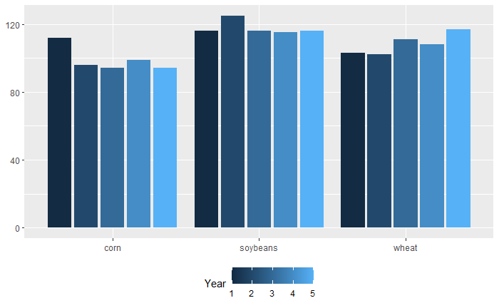

```r
test_plot <- as.data.frame(unclass(a))

ggplot(data=test_plot,
       aes(x=test_plot$cropType,
           y=test_plot$cropYield,
           fill = test_plot$year
        )) +
    geom_bar(stat="identity", position = "dodge2") +
    theme(
        plot.title = element_text("Simulation Results"),
        axis.title.x = element_blank(),
        axis.title.y = element_blank(),
        legend.position="bottom"
        ) +
    labs(fill = "Year")
```

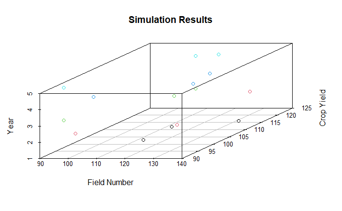

```r
scatterplot3d(test_plot$fieldNumber,
              test_plot$cropYield,
              test_plot$year,
              main = "Simulation Results",
              xlab = "Field Number",
              ylab = "Crop Yield",
              zlab = "Year",
              color = test_plot$year)
```

Reviewed for 2020 - MSP